# SOM3 - Reading and ploting data

Paixao et al. 2021. The Middle Paleolithic Ground Stones Tools of Nesher Ramla Unit V (Southern Levant): a multi-scale use-wear approach for assessing the assemblage functional variability. Quaternary International

2021-05-04 10:33:45

**Brief description of the script**

This R markdown document reads, summarizes and plots data for: *Paixao et al. 2021. The Middle Paleolithic Ground Stones Tools of Nesher Ramla Unit V (Southern Levant): a multi-scale use-wear approach for assessing the assemblage functional variability. Quaternary International*. The document contains:

1. Manuscript’s tables,
2. Manuscript’s figures (data plots),
3. Supplementary material, including extra tables and figures (data plots)

This R project and respective script follows the procedures described by Marwick et al. 2017. To compile this markdown document do not delete or move files from their original folders. Please note that the tables and figures numbering in this file do not match the numbering in the original manuscript.

For any questions, comments and inputs, please contact:

Eduardo Paixão. paixao@rgzm.de, or João Marreiros. marreiros@rgzm.de

# Load data into R project

*The imported files are in: ../data/raw_data*

```r
# Load required libraries

library(tidyverse)
library(utils)
library(knitr)
library(janitor)
library(flextable)
library(GGally)
library(doBy)
library(ggpubr)
library(tools)

# See your WD and update the following paths
# getwd()

# Load data from .csv
db1 <- read.csv("../raw_data/generaldb.csv", header=T, ",") # general database
db2 <- read.csv("../raw_data/functionaldb.csv", header=T, ",") # dataset related to functional

# On db1, convert strings to numeric and replace "," by "."
db1$length <- as.numeric(gsub(",", ".", db1$length))
db1$width <- as.numeric(gsub(",", ".", db1$width))
db1$thickness <- as.numeric(gsub(",", ".", db1$thickness))
db1$weight <- as.numeric(gsub(",", ".", db1$weight))

# Filter general dataset (only Nesher Ramla is selected here)
db1nr <- filter(db1, site  == "Nesher Ramla")

data_file <- list.files("../analysis/raw_data/", pattern = "\\.csv$", full.names = TRUE)
```

# Tables

## General Inventory

```r
# Nesher Ramla

inventory <- db1nr %>%
  group_by(raw_material, support) %>%
  summarize(total = n()) %>%
  pivot_wider(names_from = "support",
              values_from = "total",
              values_fill = 0) %>%
  adorn_totals(where = c("row", "col"), fill = "") %>%
  rename("Raw material" = raw_material, Boulder = boulder, Block = block)
write_csv(inventory, "../derived_data/generalinventory_nesher.csv")

table <- flextable(inventory)
table <- set_caption(table,caption = "General inventory of Grounds Stone tools
            from Nesher Layer 5")
knit_print(table)
```

General inventory of Grounds Stone tools from Nesher Layer 5

| Raw material | Block | Pebble | Boulder | Total |
| --- | --- | --- | --- | --- |
| Flint | 1 | 5 | 0 | 6 |
| Limestone | 68 | 392 | 7 | 467 |
| Nari | 1 | 0 | 0 | 1 |
| Total | 70 | 397 | 7 | 474 |

## Typological inventory

```r
# Nesher Ramla
type <- db1nr %>%
  group_by(raw_material, typology) %>%
  summarize(total = n()) %>%
  pivot_wider(names_from = "typology",
              values_from = "total",
              values_fill = 0) %>%
  adorn_totals(where = c("row", "col"), fill = "") %>%
  rename("Raw material" = raw_material)
write_csv(type, "../derived_data/typeinventory_nesher.csv")

table <- flextable(type)
table <- set_caption(table,caption = "Typological inventory by raw material from Nesher Ramla, Layer 5")
knit_print(table)
```

Typological inventory by raw material from Nesher Ramla, Layer 5

| Raw material | Hammerstone | Manuport | Undefined | Abrader | Anvil | Chopper | Natural | Pebble Pestle | Total |
| --- | --- | --- | --- | --- | --- | --- | --- | --- | --- |
| Flint | 1 | 4 | 1 | 0 | 0 | 0 | 0 | 0 | 6 |
| Limestone | 108 | 220 | 48 | 11 | 23 | 13 | 43 | 1 | 467 |
| Nari | 0 | 0 | 0 | 0 | 0 | 0 | 1 | 0 | 1 |
| Total | 109 | 224 | 49 | 11 | 23 | 13 | 44 | 1 | 474 |

## Morphometric analysis

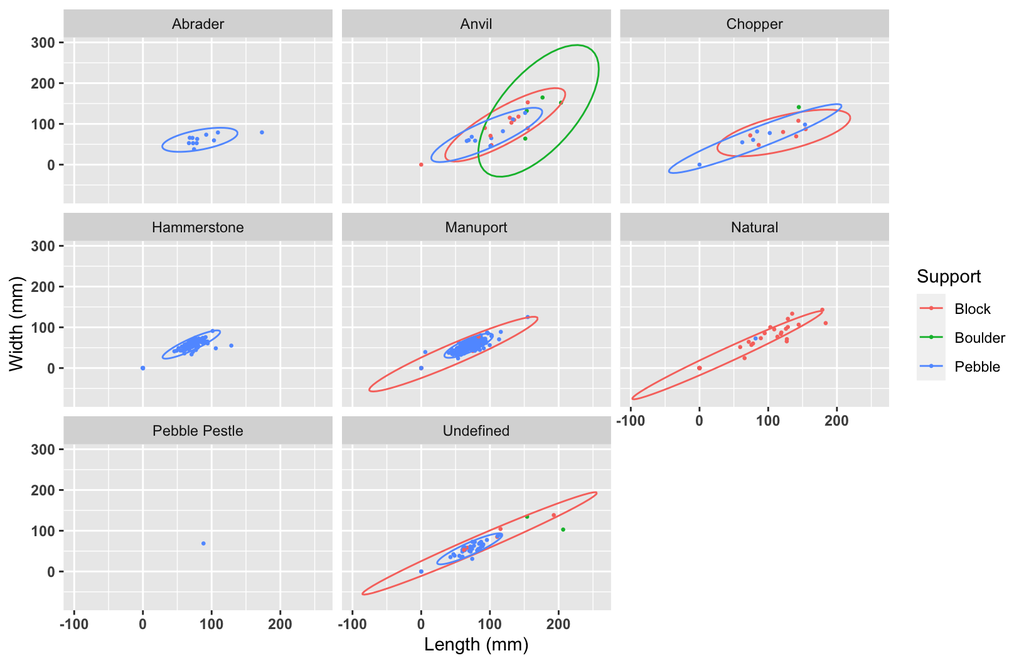

```r
# Nesher Ramla

ggplot(db1nr, aes (x = length, y = width, color = support)) +
  geom_point(size=0.5) +
  stat_ellipse() +
  labs(x="Length (mm)", y="Width (mm)", color = "Support") +
  facet_wrap(vars(typology)) +
  scale_color_discrete(labels = c("Block", "Boulder", "Pebble")) +
  theme(axis.text.x = element_text(face= "bold"), axis.text.y = element_text(face = "bold"))
```

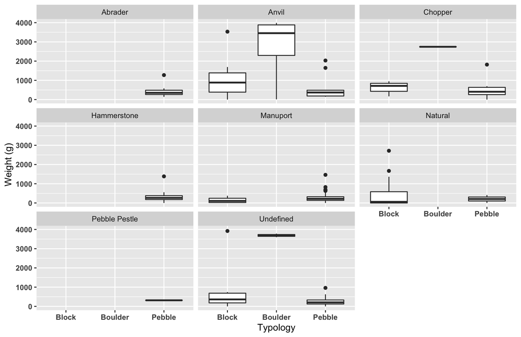

```r
ggsave("../plots/metrics_nr.png")
ggplot(db1nr, aes(x = support, y = weight)) +
  geom_boxplot() +
  labs(x="Typology", y="Weight (g)", face = "bold") +
  facet_wrap(vars(typology)) +
    scale_x_discrete(labels = c('Block','Boulder','Pebble')) +
  theme(axis.text.x = element_text(face= "bold"), axis.text.y = element_text(face = "bold"))
```

```r
p + theme(axis.text.x = element_text(face="bold", color="#993333",
                           size=14, angle=45),
          axis.text.y = element_text(face="bold", color="#993333",
                           size=14, angle=45))
```

[output not shown]

```r
ggsave("../plots/weight_nr.png")
```

## Use-wear macro damage, first observations

```r
# Nesher Ramla

# sampling observation with macro wear traces
damagenr <- filter(db1nr, usewear_macro == 'yes')

# Use-wear damage by tool typology

macrodamage <- damagenr %>%
  group_by(typology, usewear_type) %>%
  summarize(total = n()) %>%
  pivot_wider(names_from = "usewear_type",
              values_from = "total",
              values_fill = 0) %>%
  adorn_totals(where = c("row", "col"), fill = "") %>%
  rename("Typology" = typology, Mixed = mix, "Impact marks" = pecking,
         Polish = polish, Striations = striations)
write_csv(macrodamage, "../derived_data/macrodamage_nr.csv")

table <- flextable(macrodamage)
table <- set_caption(table,caption = "Use-wear damage
            organized by typology, Nesher Ramla - Layer 5")
knit_print(table)
```

Use-wear damage organized by typology, Nesher Ramla - Layer 5

| Typology | Impact marks | Polish | Striations | Mixed | Total |
| --- | --- | --- | --- | --- | --- |
| Abrader | 1 | 8 | 2 | 0 | 11 |
| Anvil | 19 | 0 | 1 | 2 | 22 |
| Chopper | 11 | 0 | 0 | 0 | 11 |
| Hammerstone | 106 | 0 | 0 | 2 | 108 |
| Pebble Pestle | 1 | 0 | 0 | 0 | 1 |
| Undefined | 7 | 16 | 3 | 7 | 33 |
| Total | 145 | 24 | 6 | 11 | 186 |

## Macro wear analysis

```r
# Nesher Ramla

# Macro wear traces by tool typology

macrowear <- db2nr %>%
  filter(!is.na(MACROTYPE)) %>%
  group_by(TYPOLOGY, MACROTYPE) %>%
  summarize(total = n()) %>%
  pivot_wider(names_from = "MACROTYPE",
              values_from = "total",
              values_fill = 0) %>%
  adorn_totals(where = c("row", "col"), fill = "") %>%
  rename("Typology" = TYPOLOGY, "Type 1" = "1", "Type 2" = "2")
```

[output not shown]

```r
write_csv(macrowear, "../derived_data/macrowear_nr.csv")
```

[output not shown]

```r
table <- flextable(macrowear)
```

[output not shown]

```r
table <- set_caption(table,caption = "Macro wear traces
            organized by typology, Nesher Ramla - Layer 5")
knit_print(table)
```

Macro wear traces organized by typology, Nesher Ramla - Layer 5

[output not shown]

## Micro wear analysis

```r
# Using db2 dataset, which contains all micro wear observations
# This only applies to Nesher Ramla (see Methods and Results chapter for more info)

microwear <- db2nr %>%
  filter(MICROTYPE %in% c("A", "B","C","D")) %>%
  group_by(TYPOLOGY, MICROTYPE) %>%
  summarize(total = n()) %>%
  pivot_wider(names_from = "MICROTYPE",
              values_from = "total",
              values_fill = 0) %>%
  adorn_totals(where = c("row", "col"), fill = "")%>%
  rename("Typology" = TYPOLOGY)
```

[output not shown]

```r
write_csv(microwear, "../derived_data/tab6.csv")
```

[output not shown]

```r
table <- flextable(microwear)
```

[output not shown]

```r
table <- set_caption(table,caption = "Micro wear type
            organized by typology, Nesher Ramla - Layer 5")
knit_print(table)
```

Micro wear type organized by typology, Nesher Ramla - Layer 5

[output not shown]

## Correlation between macro and micro wear traces

```r
# sampling observation with macro wear traces type 1
# This only applies to Nesher Ramla (see Methods and Results chapter for more info)

macro1 <- db2nr %>%
  filter(MACROTYPE == "1", MICROTYPE %in% c("A", "B","C","D")) %>%
  group_by(TYPOLOGY, MICROTYPE) %>%
  summarize(total = n()) %>%
  pivot_wider(names_from = "MICROTYPE",
              values_from = "total",
              values_fill = 0) %>%
  rename("Typology" = TYPOLOGY) %>%
  adorn_totals(where = c("row", "col"), fill = "")
```

[output not shown]

```r
write_csv(microwear, "../derived_data/macro1&micro_nr.csv")
```

[output not shown]

```r
table <- flextable(macro1)
```

[output not shown]

```r
table <- set_caption(table,caption = "Micro wear traces associated with Macro traces type 1, and organized by typology, Nesher Ramla - Layer 5")
knit_print(table)
```

Micro wear traces associated with Macro traces type 1, and organized by typology, Nesher Ramla - Layer 5

[output not shown]

```r
# sampling observation with macro wear traces type 2
# This only applies to Nesher Ramla (see Methods and Results chapter for more info)

macro2 <- db2nr %>%
  filter(MACROTYPE == "2", MICROTYPE %in% c("A", "B","C","D")) %>%
  group_by(TYPOLOGY, MICROTYPE) %>%
  summarize(total = n()) %>%
  pivot_wider(names_from = "MICROTYPE",
              values_from = "total",
              values_fill = 0) %>%
  rename("Typology" = TYPOLOGY) %>%
  adorn_totals(where = c("row", "col"), fill = "")
```

[output not shown]

```r
write_csv(microwear, "../derived_data/macro2&micro_nr.csv")
```

[output not shown]

```r
table <- flextable(macro2)
```

[output not shown]

```r
table <- set_caption(table,caption = "Micro wear traces associated with Macro traces type 2, and organized by typology, Nesher Ramla - Layer 5")
knit_print(table)
```

Micro wear traces associated with Macro traces type 2, and organized by typology, Nesher Ramla - Layer 5

[output not shown]

## Relation between different active areas and macro wear traces within and between tools

```r
# Nesher Ramla
# 2 impact areas

a <- filter(db2nr, WEAR2 == "yes")
```

[output not shown]

```r
a <- select(a, TYPOLOGY, WEAR1_MARKS_TYPE, WEAR2_MARKS_TYPE)
```

[output not shown]

```r
b <- a %>%
  unite(a, WEAR1_MARKS_TYPE, WEAR2_MARKS_TYPE, sep = "/")
```

[output not shown]

```r
amostra <- b %>%
 count(TYPOLOGY, a)
```

[output not shown]

```r
sampled <- spread(amostra, key = a, value = n)
```

[output not shown]

```r
sampled[is.na(sampled)] <- 0
```

[output not shown]

```r
twoimpac <- sampled %>%
  adorn_totals(where = c("row", "col"), fill = "")
```

[output not shown]

```r
table <- flextable(twoimpac)
```

[output not shown]

```r
table <- set_caption(table,caption = "Tools with 2 active areas
            with macro wear traces, Nesher Ramla - Layer 5")
knit_print(table)
```

Tools with 2 active areas with macro wear traces, Nesher Ramla - Layer 5

[output not shown]

```r
# 3 impact areas

a <- filter(db2nr, WEAR3 == "yes")
```

[output not shown]

```r
a <- select(a, TYPOLOGY, WEAR1_MARKS_TYPE, WEAR2_MARKS_TYPE, WEAR3_MARKS_TYPE)
```

[output not shown]

```r
b <- a %>%
  unite(a, WEAR1_MARKS_TYPE, WEAR2_MARKS_TYPE, WEAR3_MARKS_TYPE, sep = "/")
```

[output not shown]

```r
amostra <- b %>%
 count(TYPOLOGY, a)
```

[output not shown]

```r
sampled <- spread(amostra, key = a, value = n)
```

[output not shown]

```r
sampled[is.na(sampled)] <- 0
```

[output not shown]

```r
threeimpac <- sampled %>%
  adorn_totals(where = c("row", "col"), fill = "")
```

[output not shown]

```r
table <- flextable(threeimpac)
```

[output not shown]

```r
table <- set_caption(table,caption = "Tools with 3 active areas
            with macro wear traces, Nesher Ramla - Layer 5")
knit_print(table)
```

Tools with 3 active areas with macro wear traces, Nesher Ramla - Layer 5

[output not shown]

```r
# 4 impact areas

a <- filter(db2nr, WEAR4_ == "yes")
```

[output not shown]

```r
a <- select(a, TYPOLOGY, WEAR1_MARKS_TYPE, WEAR2_MARKS_TYPE,
            WEAR3_MARKS_TYPE, WEAR4_MARKS_TYPE)
```

[output not shown]

```r
b <- a %>%
  unite(a, WEAR1_MARKS_TYPE, WEAR2_MARKS_TYPE, WEAR3_MARKS_TYPE,
        WEAR4_MARKS_TYPE, sep = "/")
```

[output not shown]

```r
amostra <- b %>%
 count(TYPOLOGY, a)
```

[output not shown]

```r
sampled <- spread(amostra, key = a, value = n)
```

[output not shown]

```r
sampled[is.na(sampled)] <- 0
```

[output not shown]

```r
fourimpac <- sampled %>%
  adorn_totals(where = c("row", "col"), fill = "")
```

[output not shown]

```r
table <- flextable(fourimpac)
```

[output not shown]

```r
table <- set_caption(table,caption = "Tools with 4 active areas with
            macro wear traces, Nesher Ramla - Layer 5")
knit_print(table)
```

Tools with 4 active areas with macro wear traces, Nesher Ramla - Layer 5

[output not shown]

```r
# Use-wear location, files for GIS spatial analysis

# Hammerstones

a <- filter(db2nr, TYPOLOGY == "Hammerstone")
```

[output not shown]

```r
a <- select(a, WEAR1_LOCATION, WEAR1_MARKS_TYPE, WEAR2_MARKS_TYPE, WEAR2_LOCATION,
            WEAR3_MARKS_TYPE, WEAR3_LOCATION,
            WEAR4_MARKS_TYPE, WEAR4_LOCATION)
```

[output not shown]

```r
b <- a %>%
  unite(a, WEAR1_MARKS_TYPE, WEAR2_MARKS_TYPE, WEAR3_MARKS_TYPE,
        WEAR4_MARKS_TYPE, sep = "/")
```

[output not shown]

```r
amostra <- b %>%
 count(WEAR1_LOCATION, WEAR2_LOCATION,
       WEAR3_LOCATION, WEAR4_LOCATION, a)
```

[output not shown]

```r
sampled <- spread(amostra, key = a, value = n)
```

[output not shown]

```r
sampled[is.na(sampled)] <- 0
```

[output not shown]

```r
twoimpac <- sampled %>%
  rename("1st area" = WEAR1_LOCATION, "2nd area" = WEAR2_LOCATION, "3rd area" = WEAR3_LOCATION,
         "4th area" = WEAR4_LOCATION) %>%
  adorn_totals(where = c("row", "col"), fill = "")
```

[output not shown]

```r
table <- flextable(twoimpac)
```

[output not shown]

```r
table <- set_caption(table,caption = "Location of use-wear traces on Hammerstones, Nesher Ramla")
knit_print(table)
```

Location of use-wear traces on Hammerstones, Nesher Ramla

[output not shown]

```r
# Choppers
a <- filter(db2nr, TYPOLOGY == "Chopper")
```

[output not shown]

```r
a <- select(a, WEAR1_LOCATION, WEAR1_MARKS_TYPE, WEAR2_MARKS_TYPE, WEAR2_LOCATION)
```

[output not shown]

```r
b <- a %>%
  unite(a, WEAR1_MARKS_TYPE, WEAR2_MARKS_TYPE, sep = "/")
```

[output not shown]

```r
amostra <- b %>%
 count(WEAR1_LOCATION, WEAR2_LOCATION,a)
```

[output not shown]

```r
sampled <- spread(amostra, key = a, value = n)
```

[output not shown]

```r
sampled[is.na(sampled)] <- 0
```

[output not shown]

```r
twoimpac <- sampled %>%
  rename("1st area" = WEAR1_LOCATION, "2nd area" = WEAR2_LOCATION) %>%
  adorn_totals(where = c("row", "col"), fill = "")
```

[output not shown]

```r
table <- flextable(twoimpac)
```

[output not shown]

```r
table <- set_caption(table,caption = "Location of use-wear traces on Choppers, Nesher Ramla")
knit_print(table)
```

Location of use-wear traces on Choppers, Nesher Ramla

[output not shown]

```r
# Anvils
a <- filter(db2nr, TYPOLOGY == "Anvil")
```

[output not shown]

```r
a <- select(a, WEAR1_LOCATION, WEAR1_MARKS_TYPE, WEAR2_MARKS_TYPE, WEAR2_LOCATION,
            WEAR3_MARKS_TYPE, WEAR3_LOCATION)
```

[output not shown]

```r
b <- a %>%
  unite(a, WEAR1_MARKS_TYPE, WEAR2_MARKS_TYPE,
        WEAR3_MARKS_TYPE, sep = "/")
```

[output not shown]

```r
amostra <- b %>%
 count(WEAR1_LOCATION, WEAR2_LOCATION,
       WEAR3_LOCATION, a)
```

[output not shown]

```r
sampled <- spread(amostra, key = a, value = n)
```

[output not shown]

```r
sampled[is.na(sampled)] <- 0
```

[output not shown]

```r
twoimpac <- sampled %>%
  rename("1st area" = WEAR1_LOCATION, "2nd area" = WEAR2_LOCATION, "3rd area" = WEAR3_LOCATION) %>%
  adorn_totals(where = c("row", "col"), fill = "")
```

[output not shown]

```r
table <- flextable(twoimpac)
```

[output not shown]

```r
table <- set_caption(table,caption = "Location of use-wear traces on Anvils, Nesher Ramla")
knit_print(table)
```

Location of use-wear traces on Anvils, Nesher Ramla

[output not shown]